# Supplementary Information 1: Main Analysis

Chris Terry

26 September, 2024

# Introduction

This document outlines the code used in the analyses carried out for the paper.

## Packages and Sourcing

```r
require(igraph)
require(MASS)
require(tidyverse)
require(pracma)
require(moments)
require(rmutil)
require(cowplot)
require(knitr)
require(mvtnorm)
require(mgcv)
library(Cairo)
sapply(paste0('Scripts/',list.files('Scripts/')), source)->tmp
```

# Conducting Stability Analyses of Artificial Webs

The top-level function is `RunArtificialWebAnalysis()`.

Arguments are details of the trophic network are specified (to be passed to `BuildWeb`), along with the details (model, density and strength) of the TIMs to be added (passed to `AddTIMsToMatrix`). Different TIM distribution models are each generated by a separate function, named `AddxxxxxTIM()`. The short names used here are slightly different to those used in the paper.

`RunArtificialWebAnalysis` returns a single large data.frame where each row is an differently randomly generated model iteration and large number of columns detailing the model used, various structural features and the stability (calculated with `StabilityCriterion`, `RowColStructure`,`TIM_Dist_Examine` and `CalcDegHetero` functions ).

As a side effect these are saved as an R-object in the working directory, as per `Name`. For convenience I have also include a csv file of the generated data used in the Main Text.

```r
TIMModels<-c( 'Nearby', 'Far',
              'Normal', 'Random','Positive',
              'Negative','TightRecip','Switching')
```

```r
### Build sets of trophic networks
Repeats = 100

UnbalancedNetworks <- lapply(1:Repeats,BuildWeb,
                             size= 60,connectance  = 0.2,
                             mux=-5, muy=1,sigmax=2, sigmay = 0.5, rhoxy=-0.8)

FREQ_TO_TEST <- seq( 0, 30, by = 2)

data<-RunArtificialWebAnalysis(Name = 'Generated Data/MainResults',
                               TrophicNetworks = UnbalancedNetworks,
                               TIMStrength = 0.5,
                               Models = TIMModels,
                               FREQ_TO_TEST = FREQ_TO_TEST )

save(data, file='Generated Data/MainResults3')
```

### Loading data

```r
load('Generated Data/MainResults3')
```

# Main Text Figures

## Figure 2: Demonstration of Interaction Matrices

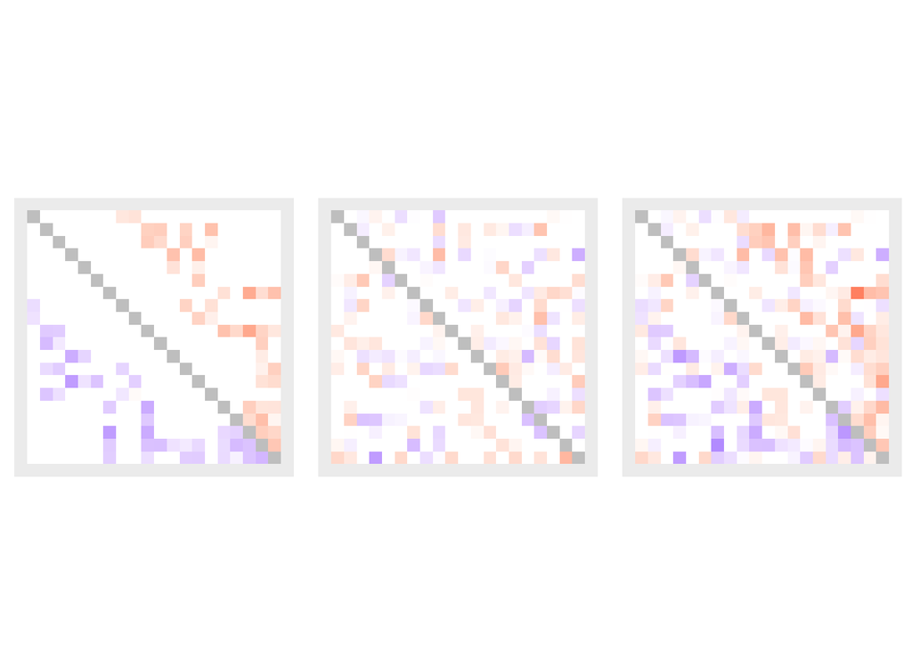

```r
set.seed(1)

J <- BuildWeb(mux = -1 , muy = 1,
              sigmax = 0.5, sigmay = 0.5, size=20,
              rhoxy = -0.8, connectance =0.2)
C <-  AddTIMsToMatrix(J,'Random',TIM_Dens = 5, TIMStrength = 0.5)

ExampleB <- PlotMatrix(J, '')
ExampleA<-PlotMatrix(C, '')
ExampleC<-PlotMatrix(C-J, '')

Combined <- plot_grid(ExampleB, ExampleC, ExampleA,  ncol=3)

labels = c('A\nFull Interaction Matrix',
           'B\n Trophic Interactions',
           'C\nNon-Trophic Interactions')
Combined
```

```r
ggsave('Paper/Figures/ExampleMatrices.png', width = 10,height = 4, dpi =200 )
```